# PyIFT Documentation

Jordão Bragantini

November 18, 2017

This reference manual is an overview of how to use PyIFT function, objects and how to update its wrapper file, `pyift.i`.

# Installing

### Dependencies

- LibIFT Latest Version
- Python >= 3.4
- NumPy >= 1.12.1
- Matplotlib >= 2.0.2

### Compiling

The PyIFT is located in the `<NEWIFT_DIR>/swig` directory.

While the PyIFT is in development it’s recommended to install this way, because we don’t need to install the module every time we updated it.

To find the correct path to install it use on your Python 3 console:

```python
import site
print(site.getsitepackages())
```

```
## ['/usr/lib/python3.6/site-packages']
```

```bash
cd <NEWIFT_DIR>/swig
make
sudo ln -s <NEWIFT_DIR>/swig/_pyift.so <PYTHON_PACKAGES_PATH>/_pyift.so
sudo ln -s <NEWIFT_DIR>/swig/pyift.py <PYTHON_PACKAGES_PATH>/pyift.py
```

When this version is complete we will be using a `setup.py` and `pip3 install` as an usual Python module to easily install this toolbox.

## PyIFT Basics

### **pyift.i Structures**

The LibIFT structures are treated similarly to C++ classes in the `pyift.i` because every object created inside a C function will not be freed by the Python garbage collector.

When adding an object to the .i file that will be used as pointer and its memory will be allocated on the inside of a function it’s necessary to extend the C struct to declare the destructor, to do this you need to declare the struct using only `typedef struct`, not the `typedef struct ift_objectname` as usual and using the swig feature `%extend` right below, this can also be used to insert Python methods into the C struct, as the example below.

The swig feature `%newobject` is designed to indicate to the target language that it should take ownership of the returned object, every function that allocates memory and don’t free it needs this feature to avoid memory leaks.

```c
typedef struct {
    int *dx, *dy, *dz;
    int n;
} iftAdjRel;

%extend iftAdjRel {
    /* Destructor */
    ~iftAdjRel() {
        iftAdjRel *ptr = ($self);
        iftDestroyAdjRel(&ptr);
    }

    PyObject* __getitem__(int i){
        PyObject *displacement = PyTuple_New(3);

        PyTuple_SetItem(displacement, 0, PyInt_FromLong(($self)->dx[i]));
        PyTuple_SetItem(displacement, 1, PyInt_FromLong(($self)->dy[i]));
        PyTuple_SetItem(displacement, 2, PyInt_FromLong(($self)->dz[i]));

        return displacement;
    }

    void Write(char* filename){
        iftAdjRel* A = ($self);
        iftWriteAdjRel(A, filename);
    }
}

/* Declaring memory allocation of new object */

%newobject iftCircular;
iftAdjRel *iftCircular(float r);
```

The `$self` is a special pointer variable that accesses the object own address.

Most of the objects in the PyIFT can be used with methods following the Object-Oriented Programming paradigm or with functions equal to the LibIFT.

### PyIFT Objects

The PyIFT toolbox includes most of C structures of the LibIFT but on the Python environment you can’t access elements inside a struct, except when using the swig feature “%extend” as described above.

Here are a few data types that are available on the PyIFT and how to use them.

#### **iftImage**

The iftImage is the main structure of the LibIFT, its default color space is YCbCr.

```python
import pyift as ift

img = ift.ReadImageByExt("Lenna.png")

# Pixels can be accessed and altered inside the C struct through Python

print("Pixel[0] (Y, Cb, Cr): " + str(img[0]))

img[0] = (1, 2, 3)

print("Pixel[0] (Y, Cb, Cr): " + str(img[0]))

# After image is initialized it can be displayed as numpy array and receive information from numpy objects

import numpy as np

# FromNumPy(np.array, shape)
img.FromNumPy(np.array([[1,2,3],[4,5,6],[7,8,9]], dtype = "int32"), (3,3))

print("Image new number of pixels: " + str(img.n))

print("Image data:")
print(img.AsNumPy())
```

```
## Pixel[0] (Y, Cb, Cr): (153, 112, 167)
## Pixel[0] (Y, Cb, Cr): (1, 2, 3)
## Image new number of pixels: 9
## Image data:
## [[[[1 2 3]
##    [4 5 6]
##    [7 8 9]]]]
```

[figure not shown]

imgplot

```python
import pyift as ift
import matplotlib.pyplot as plt

img = ift.ReadImageByExt("Lenna.png")

# Show image, must use compatible IDE
plt.imshow(img.ToPlot())

# Saving compy of Lenna.png
img.Write("copy_Lenna.png")
```

#### **iftMImage**

The iftMImage is the multi-band version of iftImage, when using its index it returns the whole image from that band index, not the pixel value as the iftImage.

```python
import pyift as ift
import matplotlib.pyplot as plt

img = ift.ReadImageByExt("Lenna.png")

mimg = ift.ImageToMImage(img, ift.YCbCr_CSPACE)

img_gray = mimg[0]
```

#### **iftFImage**

The iftFImage is the floating point variant of iftImage, it works only for grayscale images.

#### **iftLabeledSet**

The iftLabeledSet is used to store the markers from the interactive methods of image segmentation, knowing that its functionality relies on its size manipulation to easily updates its quantity as the user changes the markers on the interface, its methods emulate set (math) operations.

```python
import pyift as ift

img = ift.ReadImageByExt("airplane.png")

seeds_0 = ift.ReadSeedsComplete("airplane_0_label.txt", img)
seeds_1 = ift.ReadSeedsComplete("airplane_1_label.txt", img)

print("Seeds of Label 0")
print(seeds_0.AsDict())
print("Seeds of Label 1")
print(seeds_1.AsDict())

seeds_both = seeds_0 + seeds_1

print("Addition")
print(seeds_both.AsDict())

print("Subtraction")
print((seeds_both - seeds_1).AsDict())
```

```
## Seeds of Label 0
## {65038: 0, 65037: 0, 65036: 0, 65035: 0}
## Seeds of Label 1
## {103701: 1, 103700: 1, 103699: 1, 103698: 1}
## Addition
## {103698: 1, 103699: 1, 103700: 1, 103701: 1, 65038: 0, 65037: 0, 65036: 0, 65035: 0}
## Subtraction
## {65038: 0, 65037: 0, 65036: 0, 65035: 0}
```

#### **ifAdjRel**

This object is used to access the adjacents pixels of a given pixel, it’s mostly used as a parameter for morphology and segmentation functions.

#### **iftKernel**

It’s a weighted adjacency relation object, also known as convolution matrix.

### PyIFT Operations

PyIFT functions descriptions for image description, segmentation and math morphology.

#### iftImage **Close**(iftImage img, iftAdjRel A)

Structured removal of image region boundary pixels.

#### iftImage **Open**(iftImage img, iftAdjRel A)

Structured filling of image region boundary pixels.

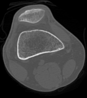

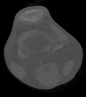

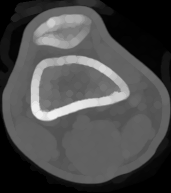

```python
import pyift as ift
import math as m

img = ift.ReadImageByExt("knee.png")

A = ift.Circular(m.sqrt(10.0))

eroded_img = ift.Erode(img, A)

eroded_img.Write("eroded-knee.png")

dilated_img = ift.Dilate(img, A)

dilated_img.Write("dilated-knee.png")
```

*Magnetic Resonance of Knee*

*Eroded Knee Image*

*Dilated Knee Image*

#### iftFImage **IntegralImage**(iftImage img)

Compute integral image of the luminance band of the image.

#### iftImage **DistTrans**(iftImage binary, iftAdjRel A, int Side)

Returns image distance transform, Side must be an integer (0: Interior, 1: Exterior, 2: Both).

#### iftFImage **MSSkel**(iftImage binary)

Multiscale skeleton by geodesic distance.

#### iftImage **SurfaceSkeleton**(iftFImage skeleton, float threshold, int number of components)

Generates surface skeleton by thresholding the geodesic skeleton than selects a given number of components.

#### iftImage **MedialAxisTrans2D**(iftImage binary, float threshold, char Side)

Runs the medial axis transform in 2D, such that the output is a 2D skeleton image with the squared Euclidian distance from the skeleton points to the objects boundaries.

#### iftImage **ShapeReconstruction**(iftImage medial axis, int reconstruction value)

It’s a shape smoothing filter that reconstructs the shape from the medial axis image.

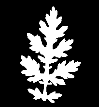

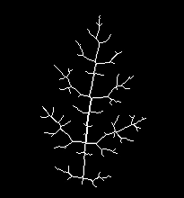

```python
import pyift as ift

leaf_img = ift.ReadImageByExt("leaf.png")

skel_leaf = ift.MSSkel(leaf_img)
skel_leaf.Write("skel_leaf.png")

neuron_img = ift.ReadImageByExt("neuron.png")

medial_axis_neuron = ift.MedialAxisTrans2D(neuron_img, 7, 0)
medial_axis_neuron.Write("medial_axis_neuron.png")

new_neuron_img = ift.ShapeReconstruction(medial_axis_neuron, 255)
new_neuron_img.Write("reconstructed_neuron.png")
```

*Leaf Image*

*Leaf Image Skeleton*

#### iftImage **EnhanceObject**(iftImage mimg, iftLabeledSet seeds, int object label)

A filter used to enhance image’s object by computing object map based on the distances between each voxel and its closest roots in each set: object root set and background root set. This method is used in pre-processing for image segmentation by watershed transforms.

#### iftImage **MEnhanceObject**(iftMImage mimg, iftLabeledSet seeds, int object label)

A filter used to enhance a MImage’s object by computing object map based on the distances between each voxel and its closest roots in each set: object root set and background root set. This method is used in pre-processment for image segmentation by watershed transforms.

#### iftImage **EnhanceEdges**(iftImage img, iftAdjRel A, iftLabeledSet seeds, float alpha)

Filter all objects in the image and then combine them resulting in the enhancement of all edges.

#### iftImage **MEnhanceEdges**(iftMImage mimg, iftAdjRel A, iftLabeledSet seeds, float alpha)

Filter all objects in the MImage and then combine them resulting in the enhancement of all edges.

#### iftImage **ImageBasins**(iftImage img, iftAdjRel A)

Computes a gradient-like image that considers the average absolute difference between voxels.

#### iftImage **ImageDomes**(iftImage img, iftAdjRel A)

Return image domes by the complement of the image’s basins.

#### iftImage **TextGradient**(iftImage img)

Compute texture gradient of given image.

#### iftImage **Watershed**(iftImage basins, iftAdjRel A, iftLabeledSet seeds, iftSet forbidden)

Computes the Watershed Transform from a set of labeled markers.

#### iftImage **WaterGray**(iftImage basins, iftImage marker, iftAdjRel A)

Watershed transforms from grayscale markers: Note that, in order to obtain a connected operator for some graph topology, the adjacency relation must be the same used to compute the input image.

#### iftImage **OrientedWatershed**(iftImage orien, const iftImage basins, iftAdjRel A, iftLabeledSet seed, int orientation, iftSet forbidden)

Computes the Watershed Transform based on a given orientation (fuzzy object map), orientation 1 if object brighter than outside, 0 if object darker than outside.

#### int **Otsu**(iftImage img)

Return threshold value by Otsu Method.

#### int **OtsuInRegion**(iftImage img)

Applies the Otsu Method in Regions defined by a Mask Image.

#### iftImage **Threshold**(iftImage img, int lowest, int highest, int value)

In case the image’s voxel has an intensity between the floor and ceiling Threshold, then, the image’s voxel receives the parameter value, otherwise, it receives 0.

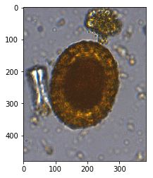

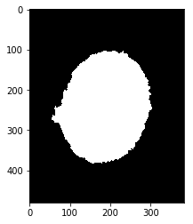

```python
import pyift as ift
import matplotlib.pyplot as plt

img = ift.ReadImageByExt("parasite.png")

A = ift.Circular(1.0)

seeds = ift.ReadSeedsComplete("parasite.txt", img)

basins = ift.ImageBasins(img, A)

label = ift.Watershed(basins, A, seeds, None)

plt.imshow(img.ToPlot())
plt.imshow(label.ToPlot())
```

*Parasite Image Plot*

*Segmentated Image Plot*